# a3_task4_lauren_skube

Lauren Skube

11/1/2020

## Summary

In this document I create a new subset from the urchins data. I then use this subset to practice creating exploratory graphs (histogram and QQ-plot) and tables of summary statistics for a statistical analysis.

```r
# Read in the urchins.csv data
urchins <- read.csv(here("data" , "urchins.csv"))
```

## Wrangle the data

```r
# Create a new subset called napl_purple_urchins
napl_purple_urchins <- urchins %>%
  clean_names() %>% # Convert all column names to lower_snake_case
  mutate(date = mdy(date)) %>% # Convert date column to "Date" class
  mutate(year = year(date) , # Create a new column containing the year
         month = month(date)) %>%  # Create a new column containing the month

# Filter the urchins data
  filter(common_name == "Purple Urchin" , # Only include Purple Urchins
         year == 2010, # Only include observation from 2010..
         month == 1, # And from January...
         site == "NAPL") %>% # And from the Naples Reef site
  group_by(treatment)
```

## Exploratory graphs

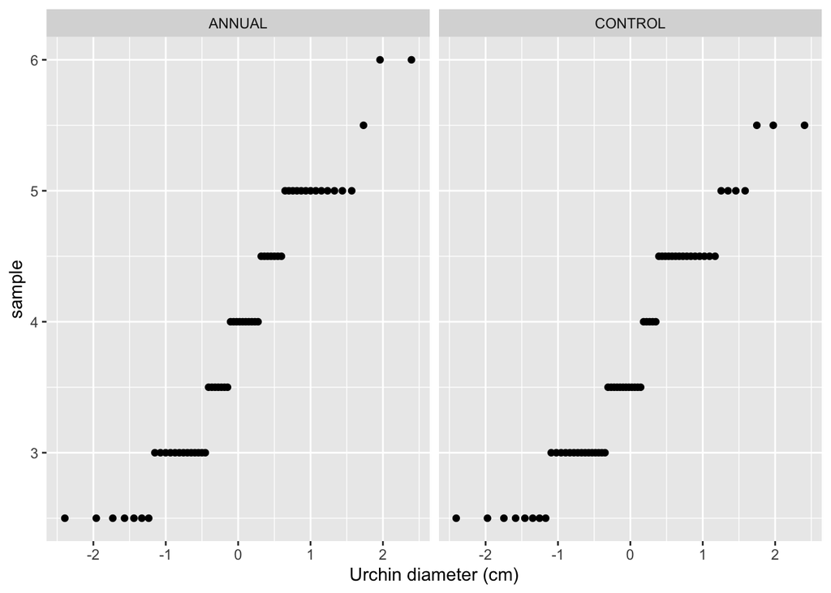

```r
# Create a quantile-quantile graph to compare the sample to normality
ggplot(data = napl_purple_urchins, aes(sample = size )) +
  geom_qq() +
  facet_wrap(~treatment) + # To separate by treatment type
  labs(x = "Urchin diameter (cm)" )
```

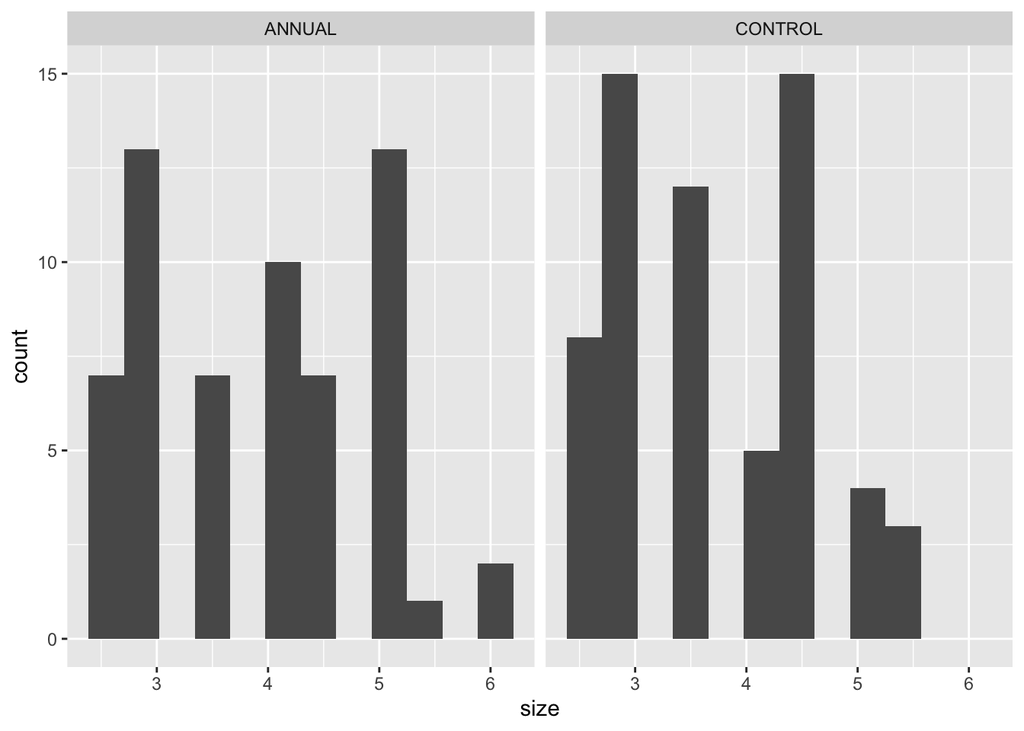

```r
# Create a histogram to compare the sample to normality
ggplot(data = napl_purple_urchins, aes(x = size)) +
  geom_histogram(bins = 12) +
  facet_wrap(~treatment)
```

## Takeaways from the graphs:

The QQ-plots follow a relatively linear pattern, with a few outliers on each end for both groups. The histograms don’t really appear to have a normal distribution. Both groups have values on either side of the central tendency that occur more frequently than the central value. The control group is also right skewed.

## Find summary statistics

```r
treatment_stats <- napl_purple_urchins %>%
  group_by(treatment) %>%
  summarise(mean_treatment = mean(size),
            sd_treatment = sd(size),
            n = n(),
            min_treatment = min(size),
            max_treatment = max(size))
```

## Perform a two-sample t-test

- This will compare the means between the annual and the control groups
- Start by creating vectors for size observations from each sample

```r
# Create vectors containing observations for each sample
control_sample <- napl_purple_urchins %>%
  filter(treatment == "CONTROL") %>%
  pull(size) # Create a vector for control group observations

annual_sample <- napl_purple_urchins %>%
  filter(treatment == "ANNUAL") %>%
  pull(size) # Create a vector for the "annual" group observations

# Run a two-sample t-test using the vectors as inputs
t.test(annual_sample, control_sample)
```

```
##
##  Welch Two Sample t-test
##
## data:  annual_sample and control_sample
## t = 1.1472, df = 117.66, p-value = 0.2536
## alternative hypothesis: true difference in means is not equal to 0
## 95 percent confidence interval:
##  -0.1386165  0.5203369
## sample estimates:
## mean of x mean of y
##  3.916667  3.725806
```

```r
# Actual difference between means:
3.916667-3.725806
```

```
## [1] 0.190861
```

```r
# Percent difference between means:
0.190861/((3.91667 + 3.72586)/2) * 100
```

```
## [1] 4.994707
```

The mean of the Naples Reef annual sample (where giant kelp is removed once each winter) is 3.92 cm. with a standard deviation of 0.966. The mean of the control sample (where giant kelp is left intact) is 3.73 cm with a standard deviation of 0.867. The actual difference between the two sample means is 0.191 cm and the percent difference is 4.99%. Without even considering the p-value, there already doesn’t seem to be a very strong difference in means between the two populations based on the actual and percent differences. When you include consideration of the p-value, which is 0.2536, it further confirms that it’s not very likely these are two populations with significantly different means.

## Meaning of the p-value

The p-value from the two-sample t-test is 0.2536. This means that if the null hypothesis is true (the samples were taken from populations with the same mean diameter size), there is a 25.36% chance that the sample means could have been at least this different by random chance. Because this probability of drawing samples that are this different by random chance is relatively high, it is not sufficient to reject the null hypothesis and say the “annual” and “control” populations have significantly different means. The removal of kelp once during winter at the Naples Reef site does not cause a significant difference in urchin size.